# Neural Network Classification

Seif Kungulio

### **Business Understanding**

#### **Problem Statement**

In this analysis, we aim to predict if a stock will pay a dividend.

### **Data Understanding**

#### **Dataset Overview**

The dataset contains six (6) variables on 200 stocks. Each row represents information on a different stock. The first or last column is typically the outcome variable in data mining. The data indicates if a stock had a dividend (Yes = 1; No = 0). In this case, “dividend” is the response variable in the first column.

#### **Data Dictionary**

| Variable | Definition | Data Type | Constraints/ Rules |
| --- | --- | --- | --- |
| **dividend** | A portion of a company’s earnings is distributed to shareholders as a return on their investment. | Integer | It must be 1 0r 0 not negative |
| **fcfps** | Free Cash Flow Per Share (fcfps) - A measure of a company’s ability to generate cash after accounting for capital expenditures, calculated by dividing free cash flow by the number of outstanding share… | Numeric | It must be number |
| **earnings_growth** | The percentage increase or decrease in a company’s earnings over a specific period indicates financial performance and future profitability. | Numeric | It must be a number |
| **de** | Debt-to-Equity Ratio (DE) - A financial metric that compares a company’s total debt to its shareholders’ equity, indicating the proportion of debt used to finance its operations relative to equity. | Numeric | It must be a number |
| **mcap** | Market Capitalization (MCAP) - The total value of a company’s outstanding shares, calculated by multiplying the current share price by the total number of shares outstanding. | Integer | It must be positive |
| **current_ratio** | A liquidity ratio that measures a company’s ability to pay its short-term liabilities with its short-term assets, calculated by dividing current assets by current liabilities. | Numeric | It must be a number |

### **Data Preparation**

#### **Load Necessary Libraries and the Dataset**

Install and Load necessary libraries

```r
# Install the libraries if they are not installed
if (!requireNamespace("neuralnet", quietly = TRUE)) {
  install.packages("neuralnet")
}
if (!requireNamespace("pROC", quietly = TRUE)) {
  install.packages("pROC")
}
if (!requireNamespace("ggplot2", quietly = TRUE)) {
  install.packages("ggplot2")
}

# Load the libraries
library(neuralnet)
library(pROC)
library(ggplot2)
```

Load the dataset and name it dividend.df

```r
dividend.df <- read.csv("../resources/dividend_info.csv")
```

Check the dimensions of the data frame

```r
dim(dividend.df)
```

```
## [1] 200   6
```

Show the first six rows to check the data

```r
head(dividend.df)
```

```
##   dividend fcfps earnings_growth   de mcap current_ratio
## 1        0  2.75          -19.25 1.11  545     0.9240557
## 2        1  4.96            0.83 1.09  630     1.4685722
## 3        1  2.78            1.09 0.19  562     1.9758751
## 4        0  0.43           12.97 1.70  388     1.9419977
## 5        1  2.94            2.44 1.83  684     2.4874670
## 6        1  3.90           -6.29 0.46  621     1.7832525
```

#### **Exploratory Data Analysis**

Determine the type (class) of each variable in R Print the list of variables

```r
variable_names <- names(dividend.df)
```

Use sapply to get the class of each variable

```r
variable_classes <- sapply(dividend.df, class)
```

Combine variable names and classes into a data frame

```r
result_df <- data.frame(Variable = variable_names, Class = variable_classes)
```

Print the result

```r
print(result_df)
```

```
##                        Variable   Class
## dividend               dividend integer
## fcfps                     fcfps numeric
## earnings_growth earnings_growth numeric
## de                           de numeric
## mcap                       mcap integer
## current_ratio     current_ratio numeric
```

Determine the type (class) of each variable in R using the str() function

```r
str(dividend.df)
```

```
## 'data.frame':    200 obs. of  6 variables:
##  $ dividend       : int  0 1 1 0 1 1 1 0 1 1 ...
##  $ fcfps          : num  2.75 4.96 2.78 0.43 2.94 3.9 1.09 2.32 2.5 4.46 ...
##  $ earnings_growth: num  -19.25 0.83 1.09 12.97 2.44 ...
##  $ de             : num  1.11 1.09 0.19 1.7 1.83 0.46 2.32 3.34 3.15 3.33 ...
##  $ mcap           : int  545 630 562 388 684 621 656 351 658 330 ...
##  $ current_ratio  : num  0.924 1.469 1.976 1.942 2.487 ...
```

Determine the summary statistics for each column

```r
summary(dividend.df)
```

```
##     dividend        fcfps       earnings_growth        de
##  Min.   :0.00   Min.   :0.070   Min.   :-19.25   Min.   :0.060
##  1st Qu.:0.00   1st Qu.:1.295   1st Qu.:  0.17   1st Qu.:1.450
##  Median :1.00   Median :2.085   Median : 11.05   Median :2.195
##  Mean   :0.51   Mean   :2.266   Mean   : 11.59   Mean   :2.138
##  3rd Qu.:1.00   3rd Qu.:3.040   3rd Qu.: 24.16   3rd Qu.:2.930
##  Max.   :1.00   Max.   :5.000   Max.   : 40.10   Max.   :3.990
##       mcap       current_ratio
##  Min.   :103.0   Min.   :0.001436
##  1st Qu.:289.5   1st Qu.:1.038044
##  Median :380.5   Median :1.508622
##  Mean   :417.9   Mean   :1.502255
##  3rd Qu.:551.2   3rd Qu.:1.960627
##  Max.   :799.0   Max.   :2.905462
```

#### **Handle Missing Values**

Check for missing values in the data

```r
missing_values <- colSums(is.na(dividend.df))
```

Print the columns with missing values and their counts

```r
print(missing_values[missing_values > 0])
```

```
## named numeric(0)
```

#### **Check and Handle Duplicates**

Check for duplicate entries in dividend.df

```r
dupes <- dividend.df[duplicated(dividend.df) | duplicated(dividend.df, fromLast = TRUE), ]
```

Print or inspect the duplicate entries

```r
print(dupes)
```

```
## [1] dividend        fcfps           earnings_growth de
## [5] mcap            current_ratio
## <0 rows> (or 0-length row.names)
```

#### **Exploration Through Visualization**

Create side-by-side box plots for 0 dividend and 1 dividend

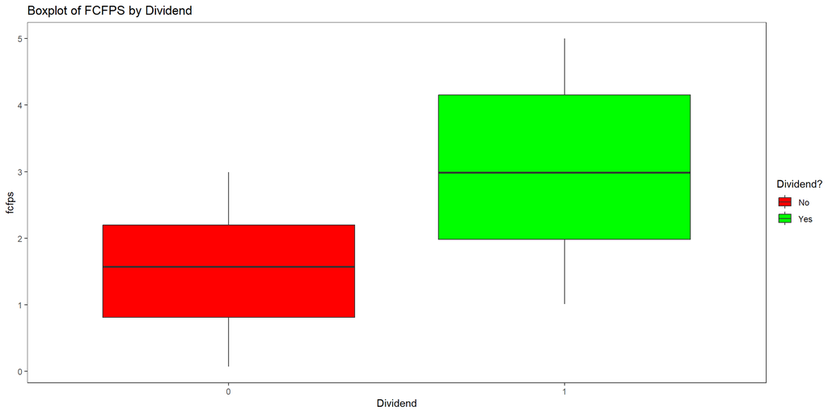

```r
ggplot(dividend.df, aes(x = as.factor(dividend),
                        y = fcfps,
                        fill = factor(dividend, labels = c("No", "Yes")))) +
  geom_boxplot() +
  labs(title = "Boxplot of FCFPS by Dividend", x = "Dividend", y = "fcfps",
       fill = "Dividend?") +
  theme_test() +
  scale_fill_manual(values = c("red", "green"))
```

Create side-by-side boxplots for dividend (x-axis) and earnings_growth (y-axis) with green and red colors

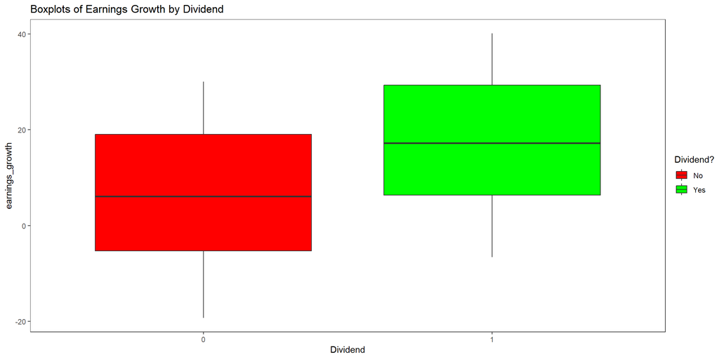

```r
ggplot(dividend.df, aes(x = as.factor(dividend),
                        y = earnings_growth,
                        fill = factor(dividend, labels = c("No", "Yes")))) +
  geom_boxplot() +  # Add boxplots
  labs(title = "Boxplots of Earnings Growth by Dividend",
       x = "Dividend",
       y = "earnings_growth",
       fill = "Dividend?") +
  theme_test() +  # Set plot theme
  scale_fill_manual(values = c("red", "green"))
```

Create side-by-side boxplots for dividend (x-axis) and de (y-axis) with green and red colors

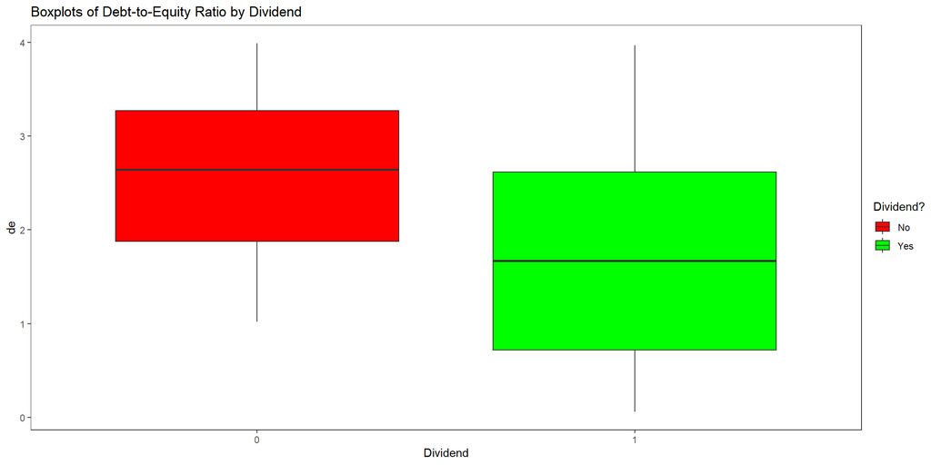

```r
ggplot(dividend.df, aes(x = as.factor(dividend),
                        y = de,
                        fill = factor(dividend, labels = c("No", "Yes")))) +
  geom_boxplot() +  # Add boxplots
  labs(title = "Boxplots of Debt-to-Equity Ratio by Dividend",
       x = "Dividend",
       y = "de",
       fill = "Dividend?") +
  theme_test() +  # Set plot theme
  scale_fill_manual(values = c("red", "green"))
```

Create side-by-side boxplots for dividend (x-axis) and market capitalization (y-axis) with green and red colors

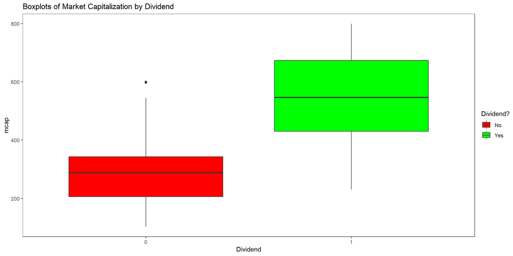

```r
ggplot(dividend.df, aes(x = as.factor(dividend),
                        y = mcap,
                        fill = factor(dividend, labels = c("No", "Yes")))) +
  geom_boxplot() +  # Add boxplots
  labs(title = "Boxplots of Market Capitalization by Dividend",
       x = "Dividend", y = "mcap", fill = "Dividend?") +  # Set plot title and axis
  theme_test() +  # Set plot theme
  scale_fill_manual(values = c("red", "green"))
```

```r
# Remove rows where mcap is greater than 580
dividend.df <- dividend.df[dividend.df$mcap <= 580, ]
```

Create side-by-side boxplots for dividend (x-axis) and current_ratio (y-axis) with green and red colors

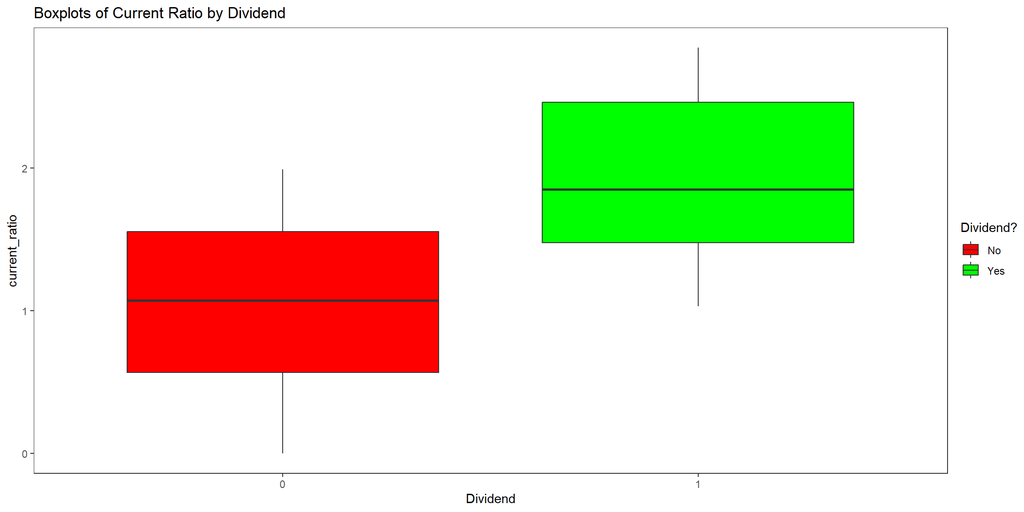

```r
ggplot(dividend.df, aes(x = as.factor(dividend),
                        y = current_ratio,
                        fill = factor(dividend, labels = c("No", "Yes")))) +
  geom_boxplot() +  # Add boxplots
  labs(title = "Boxplots of Current Ratio by Dividend",
       x = "Dividend", y = "current_ratio", fill = "Dividend?") +  # Set plot title and axis labels
  theme_test() +  # Set plot theme
  scale_fill_manual(values = c("red", "green"))
```

### **Modeling**

#### **Clean and Transform the Dataset**

Normalize the data

```r
# Max-min normalization
normalize <- function(x) {
  return ((x - min(x)) / (max(x) - min(x)))
}
# Run the function across the existing data
# Save the scaled dataset normalized.df
normalized.df <- as.data.frame(lapply(dividend.df, normalize))
```

Partition the data into 60% training and 40% testing. Randomly select 60% of the row IDs for training and the remaining 40% will be the testing data.

```r
# Set seed for reproducibility
set.seed(123)
training.rows <- sample(1:nrow(normalized.df), nrow(normalized.df) * 0.6)
```

Organize all of the columns with the training row ID into the training set

```r
training.data <- normalized.df[training.rows, ]
head(training.data)
```

```
##     dividend     fcfps earnings_growth        de      mcap current_ratio
## 14         0 0.5202559      0.25779275 0.5165394 0.5074310     0.5032139
## 50         0 0.5245203      0.13108677 0.5470738 0.3885350     0.7001953
## 118        1 0.9658849      0.26436394 0.1094148 0.5562633     0.9575007
## 43         0 0.1407249      0.05914069 0.4809160 0.3099788     0.1825572
## 154        0 0.3262260      0.12906487 0.7480916 0.6029724     0.1536242
## 152        1 0.2324094      0.95214827 0.6132316 0.6390658     0.3789132
```

Assign row IDs that are not in the training set into the testing set

```r
testing.rows <- setdiff(1:nrow(normalized.df), training.rows)
testing.data <- normalized.df[-training.rows, ]
head(testing.data)
```

```
##    dividend      fcfps earnings_growth         de      mcap current_ratio
## 1         0 0.57142857       0.0000000 0.26717557 0.9384289     0.3248896
## 2         1 0.57782516       0.3427127 0.03307888 0.9745223     0.6952753
## 3         0 0.07675906       0.5428812 0.41730280 0.6050955     0.6833458
## 5         1 0.93603412       0.7199663 0.83206107 0.4819533     0.9902471
## 9         0 0.21108742       0.7366470 0.45292621 0.1061571     0.6492616
## 10        1 0.65884861       0.7346251 0.70229008 0.6539278     0.4971687
```

Check the distribution of subscriptions rates across training and testing set

```r
# to ensure the subsets are balanced
prop.table(table(training.data$dividend))
```

```
##
##         0         1
## 0.6304348 0.3695652
```

```r
prop.table(table(testing.data$dividend))
```

```
##
##         0         1
## 0.6129032 0.3870968
```

#### **Build the Model**

Train the neural network model

```r
# Regress the dependent variable, dividend, against all the independent variables
# Set the number of hidden layers to (2,1)
# Set linear.output to FALSE (assume the relationship is non-linear)
# Set threshold to 0.01 A change in error for an iteration less than 1% will stop
# the optimization of the model
nn <- neuralnet(dividend ~ ., data = training.data, hidden = c(2,1),
                linear.output = FALSE, threshold = 0.01)
```

Generate the error of the neural network and the weights between the inputs, hidden layers, and outputs

```r
nn$result.matrix
```

```
##                                      [,1]
## error                         0.509796456
## reached.threshold             0.008677528
## steps                       560.000000000
## Intercept.to.1layhid1         1.417229546
## fcfps.to.1layhid1            -2.057312420
## earnings_growth.to.1layhid1   0.543310736
## de.to.1layhid1                0.816817777
## mcap.to.1layhid1             -5.366661798
## current_ratio.to.1layhid1    -0.652381891
## Intercept.to.1layhid2         2.824504644
## fcfps.to.1layhid2            -2.975473092
## earnings_growth.to.1layhid2  -4.341368774
## de.to.1layhid2                3.655652350
## mcap.to.1layhid2             -3.197997255
## current_ratio.to.1layhid2    -2.509617042
## Intercept.to.2layhid1        -3.699640078
## 1layhid1.to.2layhid1         15.491920437
## 1layhid2.to.2layhid1          8.625380348
## Intercept.to.dividend        11.550307107
## 2layhid1.to.dividend        -25.623076887
```

The output shown above represents the result matrix of the neural network model (nn$result.matrix). Here’s what each section of the matrix represents:

- **Error:** The error value of the neural network model. It indicates how well the model fits the training data. Lower error values generally indicate better performance.
- **Reached Threshold:** Indicates whether the optimization algorithm reached the specified threshold. In this case, the value suggests whether the error reduction in each iteration was below the defined threshold.
- **Steps:** The number of iterations (steps) performed during the training process. This represents how many times the model parameters were updated as part of the training process.
- **Intercept to Hidden Layer 1 Weight:** These represent the weights connecting the intercept (bias term) to the neurons in the first hidden layer.
- **Input Variables to Hidden Layer 1 Weight:** These represent the weights connecting the input variables (features) to the neurons in the first hidden layer.
- **Intercept to Hidden Layer 2 Weights:** These represent the weights connecting the intercept (bias term) to the neurons in the second hidden layer.
- **Hidden Layer 1 to Hidden Layer 2 Weights:** These represent the weights connecting the neurons in the first hidden layer to the neurons in the second hidden layer.
- **Intercept to Output Layer (Dividend) Weights:** These represent the weights connecting the intercept (bias term) to the output neurons (in this case, predicting dividends).
- **Hidden Layer 2 to Output Layer (Dividend) Weights:** These represent the weights connecting the neurons in the second hidden layer to the output neurons (predicting dividends).

#### **Plot the neural network model**

Plot the neural network

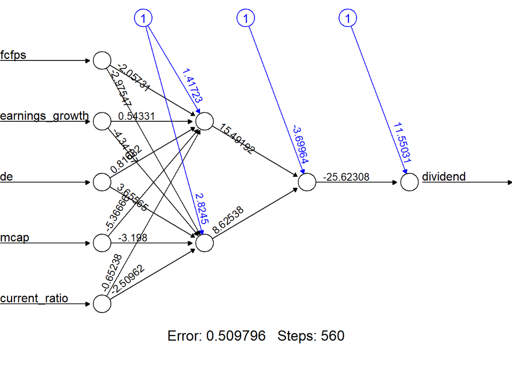

```r
plot(nn, rep = "best", mar = c(5, 10, 4, 2) + 0.5)
```

- The plot enables us to visually inspect the structure and connections of the neural network model. The line of code **plot(nn, rep=“best”)** plots the neural network model stored in the variable **nn**. The plot function is used to visualize the neural network architecture, including the connections between nodes (neurons) in different layers.
- The **rep** parameter specifies the method used to represent the neural network. In this case, **“best”** is specified, which typically tries to arrange the nodes visually appealingly, optimizing the layout for readability. Here, we used the **rep = “best”** argument to specify the best plot representation, typically based on the number of input and output variables.
- The **mar** parameter is used to adjust the margins of the plot to ensure that all components are adequately displayed.

#### **Testing the result**

Test the resulting output using the test data

```r
# Subset the testing data to remove the dependent variable
temp_test <- subset(testing.data,
                    select = c("fcfps", "earnings_growth", "de", "mcap", "current_ratio"))
# Show the temporary (temp) testing data
head(temp_test)
```

```
##         fcfps earnings_growth         de      mcap current_ratio
## 1  0.57142857       0.0000000 0.26717557 0.9384289     0.3248896
## 2  0.57782516       0.3427127 0.03307888 0.9745223     0.6952753
## 3  0.07675906       0.5428812 0.41730280 0.6050955     0.6833458
## 5  0.93603412       0.7199663 0.83206107 0.4819533     0.9902471
## 9  0.21108742       0.7366470 0.45292621 0.1061571     0.6492616
## 10 0.65884861       0.7346251 0.70229008 0.6539278     0.4971687
```

Use the compute() function to create the prediction variable

```r
nn.results <- compute(nn, temp_test)
```

Compare the predicted data to the actual data

```r
results <- data.frame(actual = testing.data$dividend,
                      prediction = nn.results$net.result)
```

Show the comparison of the actual to the predicted values

```r
results
```

```
##     actual   prediction
## 1        0 9.998908e-01
## 2        1 9.999805e-01
## 3        0 7.370089e-01
## 5        1 9.999386e-01
## 9        0 7.765365e-07
## 10       1 9.999246e-01
## 11       1 9.999695e-01
## 15       0 7.731715e-07
## 18       1 9.982840e-01
## 19       1 9.999463e-01
## 20       1 9.999796e-01
## 24       0 7.731948e-07
## 28       0 8.912284e-07
## 29       0 1.646404e-06
```

[output cut: 48 more lines]

### **Evaluation**

#### **Evaluate model performance**

Since this is a Neural Network problem, we will focus on accuracy, confusion matrix, recall (sensitivity), precision, F1 score, and receiver operating characteristic (ROC) curve.

- **Accuracy:** Accuracy measures the proportion of correctly classified observations out of the total number of observations. While accuracy provides a general measure of model performance, it may not be suitable for imbalanced datasets where one class dominates the other.
- **Confusion Matrix:** A confusion matrix provides a more detailed breakdown of correct and incorrect classifications. It consists of four components: true positives (TP), true negatives (TN), false positives (FP), and false negatives (FN). Various metrics can be derived from the confusion matrix, including sensitivity, specificity, precision, and F1-score.
- **Recall (Sensitivity):** Recall measures the proportion of actual positive cases the model correctly identifies. It indicates the model’s ability to detect the positive class. Recall is important when the cost of false negatives is high.
- **Precision:** Precision measures the proportion of true positive cases among all predicted positive cases. It represents the model’s accuracy in predicting positive cases. Precision is instrumental when the cost of false positives is high.
- **F1-Score:** The F1-score is the harmonic mean of precision and recall (sensitivity). It provides a balanced measure of the model’s performance, especially in the presence of class imbalance.
- **Receiver Operating Characteristic (ROC) Curve:** The ROC curve represents the trade-off between sensitivity and specificity across different thresholds. The area under the ROC curve (AUC-ROC) is a commonly used metric that quantifies the model’s overall performance, with higher values indicating better discrimination ability.

#### **Accuracy**

Calculate accuracy

```r
# Convert the predicted values to binary classes (0 or 1) based on a threshold
predicted_classes <- ifelse(nn.results$net.result > 0.5, 1, 0)

# Compute accuracy
accuracy <- mean(predicted_classes == testing.data$dividend)
cat("Accuracy:", accuracy)
```

```
## Accuracy: 0.8387097
```

The model achieved an accuracy of 83.87%, meaning it correctly predicted whether a stock would have a dividend 83.87% of the time. This suggests the model performs well in distinguishing between dividend-paying and non-dividend-paying stocks based on the provided features. However, the significance of this accuracy depends on the specific application, as it may be considered good or insufficient depending on the requirements.

#### **Confusion Matrix**

Create the confusion matrix

```r
conf_matrix <- table(testing.data$dividend, predicted_classes)
```

Print the confusion matrix

```r
conf_matrix
```

```
##    predicted_classes
##      0  1
##   0 28 10
##   1  0 24
```

```r
# Extract individual values
TP <- conf_matrix[2, 2]  # True Positives
TN <- conf_matrix[1, 1]  # True Negatives
FP <- conf_matrix[1, 2]  # False Positives
FN <- conf_matrix[2, 1]  # False Negatives
```

```
## True Positives (TP): 24
```

```
## True Negatives (TN): 28
```

```
## False Positives (FP): 10
```

```
## False Negatives (FN): 0
```

The numbers in the matrix represent the counts of instances falling into the following categories:

- **True Positives (TP):** This is the count of stocks correctly predicted to have dividends (actual dividend = 1, predicted dividend = 1). In our case there are 24 true positives.
- **False Positives (FP):** This is the count of stocks incorrectly predicted to have dividends (actual dividend = 0, predicted dividend = 1). In our case there are 10 false positives.
- **True Negatives (TN):** This is the count of stocks correctly predicted not to have dividends (actual dividend = 0, predicted dividend = 0). In our case there are 28 true negatives.
- **False Negatives (FN):** This is the count of stocks incorrectly predicted not to have dividends (actual dividend = 1, predicted dividend = 0). In our case there are 0 false negatives.

#### **Sensitivity (Recall)**

Calculate recall (sensitivity)

```r
recall <- TP / (TP + FN)
```

```
## Recall (Sensitivity): 1
```

The model has a sensitivity (recall) of 1.00, meaning it correctly identifies all dividend-paying stocks without missing any. This high sensitivity indicates the model is effective at detecting dividend-paying stocks and has a low rate of false negatives. However, perfect sensitivity may suggest potential overfitting, so it’s important to evaluate the model on test data and consider other metrics like precision, accuracy, and the specific context to assess its overall performance.

#### **Precision**

Calculate precision

```r
# True positives: predicted dividend and actual dividend
true_positives <- sum(predicted_classes == 1 & testing.data$dividend == 1)

# False positives: predicted dividend but not actual dividend
false_positives <- sum(predicted_classes == 1 & testing.data$dividend == 0)

# Precision = True Positives / (True Positives + False Positives)
precision <- true_positives / (true_positives + false_positives)
```

```
## Precision: 0.7058824
```

The model’s precision is 0.7059, meaning that 70.59% of the instances predicted as dividend-paying stocks are correct. Precision reflects the accuracy of the model’s positive predictions, indicating that the model has a moderate ability to identify dividend-paying stocks. A value closer to 1.0 would suggest fewer false positives, while a lower value points to a higher chance of incorrect predictions. While the precision of 0.7059 shows good performance, there is still room for improvement in reducing false positives.

#### **F1-Score**

Calculate F1-score

```r
# F1-score = 2 * (Precision * Recall) / (Precision + Recall)
f1_score <- 2 * (precision * recall) / (precision + recall)
```

```
## F1-score: 0.8275862
```

The model’s F1-score is 0.8276, which reflects a good balance between precision and recall. It combines both metrics into a single value, providing a comprehensive measure of the model’s performance. The score suggests that the model is effective at both making accurate positive predictions and capturing a high proportion of actual positive instances. While an F1-score closer to 1.0 would indicate even better performance, the current score demonstrates that the model performs well in predicting dividend-paying stocks.

#### **Receiver Operating Characteristic (ROC) Curve**

Calculate ROC curve and AUC

```r
# Extract predicted probabilities for class 1 (dividends)
# Convert predicted probabilities to numeric vector
predicted_probabilities <- as.numeric(nn.results$net.result)
```

Compute ROC curve

```r
roc_curve <- roc(testing.data$dividend, predicted_probabilities)
```

Plot ROC curve

```r
plot(roc_curve, main = "ROC Curve", col = "blue")
abline(a = 0, b = 1, lty = 2, col = "red")  # Diagonal reference line

# Calculate AUC
auc_score <- auc(roc_curve)
cat("AUC score:", auc_score)
```

```
## AUC score: 0.9791667
```

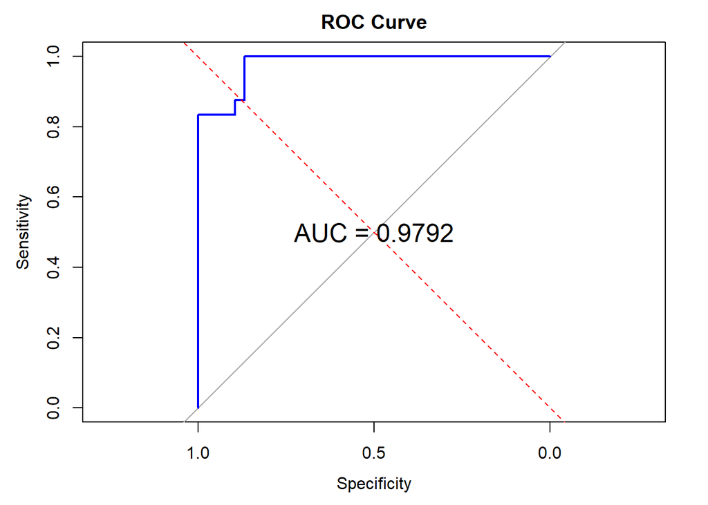

```r
# Add AUC value to plot
text(0.5, 0.5, paste("AUC =", round(auc_score, 4)),
     adj = c(0.5, 0.5), cex = 1.5, col = "black")
```

The model’s AUC value is 0.9792, indicating excellent performance in distinguishing between dividend-paying and non-dividend-paying stocks. AUC values range from 0 to 1, with 1 representing perfect discrimination and 0.5 indicating random guessing. An AUC of 0.9792 suggests the model has strong discriminatory power, effectively ranking positive instances higher than negative ones, with a very low chance of mis-classification. This score indicates the model is highly effective in predicting whether a stock will have a dividend.

#### **Model Evaluation Summary**

The evaluation metrics provide a thorough assessment of the neural network model’s performance in predicting dividend outcomes. The model’s accuracy of 83.87% shows it correctly predicts dividends most of the time. With a sensitivity of 1.000, it excels at identifying dividend-paying stocks without missing any. Its precision of 0.7059 indicates that most predicted dividend stocks are accurate, but there is room for improvement in reducing false positives. The F1-score of 0.8276 reflects a good balance between precision and recall. The high AUC value of 0.9792 demonstrates excellent discriminatory power, indicating the model effectively differentiates between positive and negative cases. Overall, while the model performs well, further refinement, especially to improve precision, is recommended for better real-world application.

### **Model Tuning**

Tuning a model with backpropagation is essential for enhancing performance and optimizing predictive accuracy. Backpropagation iteratively adjusts the weights of the network by propagating errors backward, enabling the model to learn from mistakes and improve over time. Key benefits include:

- **Optimizing Weights:** It helps find the best weight combination, minimizing prediction errors and improving accuracy.
- **Learning Complex Patterns:** Neural networks can capture intricate data patterns, with backpropagation adjusting weights to identify meaningful features.
- **Reducing Overfitting:** It prevents the model from memorizing data, helping it generalize better to unseen data.
- **Improving Convergence:** By efficiently updating weights, backpropagation accelerates convergence, saving time and resources.
- **Adapting to Data Changes:** Periodic tuning allows the model to adapt to evolving data, maintaining its effectiveness.

Overall, backpropagation is crucial for maximizing predictive performance, improving learning, and adapting to changing data.

```r
nn_tuned <- neuralnet(dividend ~ ., data = training.data,
                      hidden = c(4,1), linear.output = FALSE, threshold = 0.01)
```

Generate the error of the tuned neural network and the weights between the inputs, hidden layers, and outputs

```r
nn_tuned$result.matrix
```

```
##                                      [,1]
## error                         1.018286510
## reached.threshold             0.009432249
## steps                       224.000000000
## Intercept.to.1layhid1         2.578269529
## fcfps.to.1layhid1            -1.835535791
## earnings_growth.to.1layhid1  -1.578154305
## de.to.1layhid1                1.379201237
## mcap.to.1layhid1             -2.758854265
## current_ratio.to.1layhid1    -0.152648842
## Intercept.to.1layhid2        -2.834846860
## fcfps.to.1layhid2             1.112599062
## earnings_growth.to.1layhid2   1.109532886
## de.to.1layhid2               -0.997440877
## mcap.to.1layhid2              2.643189146
## current_ratio.to.1layhid2     2.139437963
## Intercept.to.1layhid3        -2.333520320
## fcfps.to.1layhid3             2.381671631
## earnings_growth.to.1layhid3   1.509025746
## de.to.1layhid3               -2.339299793
## mcap.to.1layhid3              2.200354080
## current_ratio.to.1layhid3     1.836414254
## Intercept.to.1layhid4        18.064332789
## fcfps.to.1layhid4            18.590092005
## earnings_growth.to.1layhid4  16.021511059
## de.to.1layhid4               19.301130151
## mcap.to.1layhid4             17.912986353
## current_ratio.to.1layhid4    17.346517334
## Intercept.to.2layhid1         1.272635835
## 1layhid1.to.2layhid1          5.011568134
## 1layhid2.to.2layhid1         -4.935487122
## 1layhid3.to.2layhid1         -4.768820408
## 1layhid4.to.2layhid1          0.355503872
## Intercept.to.dividend         5.243161682
## 2layhid1.to.dividend        -19.456504536
```

#### **Plot the Neural Network Model**

Plot the neural network

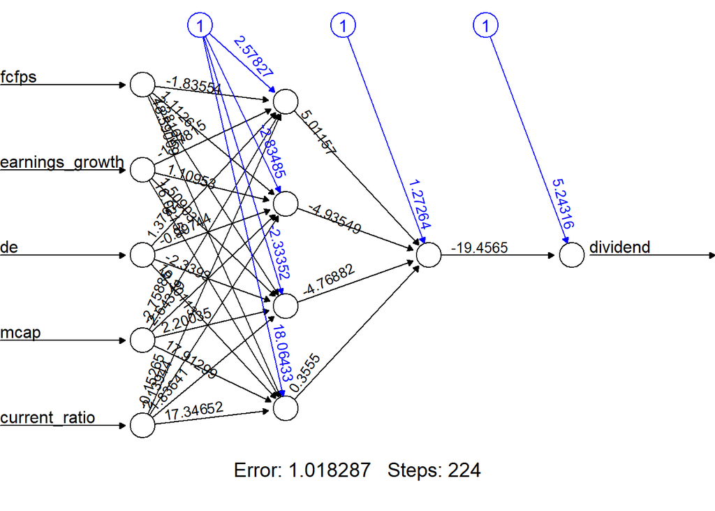

```r
plot(nn_tuned, rep = "best", mar = c(5, 10, 4, 2) + 0.5)
```